# NF03 · Local crowding & collective motion

An earlier exploratory draft (`DV-motility_metrics_sanity_check.ipynb`) tested "isolated vs. crowded" neighbor-density groups against many columns, but only on the 2,130 cells that link to Cell Painting. Here we compute local density for **every detected cell in every live frame** (~300k cell-frame rows, no tracking/linking/final-frame restriction) via a per-frame KD-tree, and ask: does local crowding predict instantaneous speed? Bonus: is there evidence of coordinated ("flocking") motion between nearby cells?

## 1 · Local density, all detected cells, all live frames

```
282,178 detected cells across 60 live frames
```

```
count    282178.000000
mean          4.303425
std           2.855956
min           0.000000
25%           2.000000
50%           4.000000
75%           6.000000
max          22.000000
Name: neighbor_count, dtype: float64
```

## 2 · Density vs. instantaneous speed, all tracked cells (continuous, not just linked-to-CP)

```
186,840 tracked cell-frame steps with a matching density value
Spearman(neighbor_count, step_speed_um) = -0.091, p = 0, n = 186,840
```

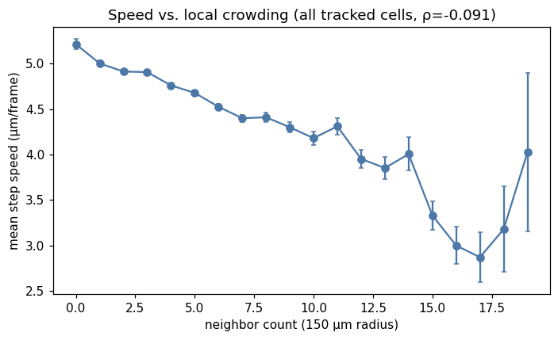

## 3 · Isolated vs. crowded (generalized): Welch's t-test + BH-FDR

Reproduces the earlier draft's isolated (0 neighbors) vs. crowded (>=5 neighbors) comparison, but on the full live-trajectory population instead of just the 2,130 CP-linked cells, and against LCI-only features (motility metrics + the shape-over-time summary from NF02) since most cells here have no CP match.

```
isolated (mean nbrs <1): 222 | crowded (mean nbrs >=5): 1,425
13 / 26 features significant after BH-FDR
```

|  | feature | t | p | isolated_mean | crowded_mean | p_adj | significant |
| --- | --- | --- | --- | --- | --- | --- | --- |
| 22 | equivalent_diameter_mean | 7.805724 | 1.017015e-13 | 16.934110 | 15.485750 | 1.322120e-12 | True |
| 14 | area_mean | 7.820011 | 9.645215e-14 | 233.585522 | 196.304885 | 1.322120e-12 | True |
| 16 | perimeter_mean | 6.905334 | 2.868788e-11 | 59.916580 | 55.212229 | 2.486283e-10 | True |
| 12 | path_length_um | 4.126386 | 4.801246e-05 | 223.731975 | 190.446957 | 1.929361e-04 | True |
| 13 | mean_step_um | 4.115748 | 5.194434e-05 | 6.393794 | 5.070380 | 1.929361e-04 | True |
| 9 | mean_step | 4.115748 | 5.194434e-05 | 1.967321 | 1.560117 | 1.929361e-04 | True |
| 7 | path_length | 4.126386 | 4.801246e-05 | 68.840608 | 58.599064 | 1.929361e-04 | True |
| 25 | form_factor_cv | 3.618377 | 3.542329e-04 | 0.089441 | 0.075009 | 1.151257e-03 | True |
| 1 | start_y | 3.423717 | 7.233240e-04 | 1616.658481 | 1380.241328 | 1.880642e-03 | True |
| 3 | end_y | 3.439238 | 6.848829e-04 | 1617.471433 | 1380.223256 | 1.880642e-03 | True |
| 20 | elongation_mean | -2.713283 | 6.997272e-03 | 1.300884 | 1.337798 | 1.653901e-02 | True |
| 23 | equivalent_diameter_cv | 2.557181 | 1.107642e-02 | 0.118313 | 0.107121 | 2.399891e-02 | True |

## Bonus · Collective motion: velocity correlation vs. distance

If nearby cells move in correlated directions (beyond what crowding-vs-speed alone shows), that's evidence of coordinated/"flocking" migration rather than independent movement.

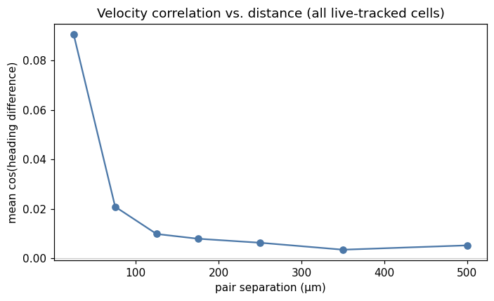

|  | bin_left_um | bin_right_um | mean_cos_similarity | n_pairs |
| --- | --- | --- | --- | --- |
| 0 | 0 | 50 | 0.090447 | 20740 |
| 1 | 50 | 100 | 0.020828 | 106979 |
| 2 | 100 | 150 | 0.009791 | 167841 |
| 3 | 150 | 200 | 0.007869 | 230767 |
| 4 | 200 | 300 | 0.006245 | 641812 |
| 5 | 300 | 400 | 0.003431 | 901101 |
| 6 | 400 | 600 | 0.005177 | 2499409 |

## ⭐ Key finding

*(Corrected: an earlier pass accidentally included post-fixation frames -- now explicitly filtered to `frame_index <= MOTILITY_LAST_FRAME`. This also exposed a second bug: once capped, `frame_last` becomes ~constant, and a zero-variance t-test's NaN silently corrupted the whole BH-FDR vector -- both are now excluded/guarded against.)*

**Crowded cells move measurably slower.** Across **186,840 tracked cell-frame steps** (all live trajectories, not just CP-linked ones), local neighbor count (150 µm radius) correlates negatively with instantaneous step speed: Spearman ρ = **−0.091** (p ≈ 0) -- this number is unaffected by the fix since the density join already implicitly excluded post-fixation steps. The generalized isolated-vs-crowded comparison (222 isolated / 1,425 crowded trajectories, by mean neighbor count) confirms this at the trajectory level: isolated cells average **6.39 µm/frame** vs. **5.07 µm/frame** for crowded cells (both `mean_step_um` and `path_length_um`, BH-FDR significant). **13 of 26** LCI features tested survive BH-FDR -- isolated cells are also consistently **larger** (`area_mean` 234 vs. 196 px², `equivalent_diameter_mean` 16.9 vs. 15.5 px), suggesting crowding may restrict both spreading and movement (contact inhibition-like behavior), not just an incidental correlation.

**Bonus — collective motion:** velocity direction correlation between cell pairs is consistently positive and decays with distance (mean cos-similarity 0.090 at 0-50 µm down to ~0.003-0.005 beyond 300 µm, n up to 2.5M pairs at the largest bin) — weak but real local coordination in migration direction, on top of (and distinct from) the crowding-slows-speed effect above.

**Caveat:** this notebook's step-level signal-to-noise ratio is low (see NF01's caveats section -- post-fixation "should be motionless" steps measure ~95% of the live median step size), and the tracker's distance-fallback/gap-bridging links are more likely to mislink in dense regions. If mislinking is more common in crowded areas and produces artificially smaller apparent displacement, that alone could partly explain "crowded cells look slower" without real biology behind it. Not yet ruled out -- see NF01 for the proposed overlap-only-vs-fallback comparison.